# Egymintás próbák

## Alapfogalmak és kérdések

- Mi a statisztikai hipotézis?
- Milyen a jó hipotézis?
- Mire vonatkozik a hipotézis?
- Milyen paraméterekre, jellemzőkre vonatkozhat?
- Minek végzünk hipotézisvizsgálatot?
- Mi a nullhipotézis / ellenhipotézis? Milyen ezek viszonya?
- Mi az első / másodfajú hiba?
- Mi a nulleloszlás?
- Mit jelent, hogy egy próba szignifikáns?

## Nullhipotézis / ellenhipotézis

\(H_0\): nincs összefüggés / különbség  
\(H_1\): van összefüggés / különbség (egyik vagy mindkét irányba)

Egymást kizárók:  
pl.

\(H_0: \mu = 170\)  
\(H_1: \mu \ne 170\)  
vagy:  
\(H_1: \mu < 170\)  
vagy:  
\(H_1: \mu > 170\)

## Elsőfajú és másodfajú hiba

Két esetben döntünk jól:

- \(H_0\) igaz, és megtartjuk
- \(H_0\) nem igaz, és elvetjük

Kétféle hibát követhetünk el:

- \(H_0\) nem igaz, de megtartjuk
- \(H_0\) igaz, de elvetjük

Mit gondolnak, melyik a súlyosabb?

## Elsőfajú és másodfajú hiba

**Elsőfajú hiba**: a nullhipotézis igaz (⇒ nincs összefüggés), mi mégis elvetjük

Hamis pozitív eredmény

**Másodfajú hiba**: a nullhipotézis nem igaz (⇒ van összefüggés), de mi megtartjuk

Hamis negatív eredmény

Az egyik valószínűségének csökkentése sajnos növeli a másikat.

## Elsőfajú és másodfajú hiba

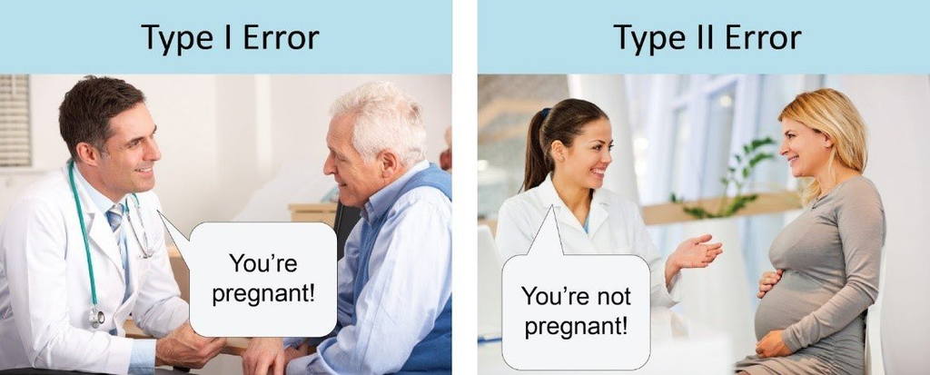

## Nulleloszlás

Minden próbához tartozik egy nulleloszlás:

**Ha igaz a nullhipotézis**, akkor a próba ilyen eloszlású változó.

A saját próbánk értékét összevetjük ezzel az eloszlással: mennyire extrém? Ha túl kicsi annak a valószínűsége, hogy igaz nullhipotézis esetén ilyen tesztértéket kapjunk, akkor elvetjük a nullhipotézist.

## Szignifikáns próba

**Szignifikanciaszint** (jele: α): annak a valószínűsége, hogy **ha igaz a nullhipotézis**, ilyen vagy ennél extrémebb tesztértéket kapjunk. Csak akkor vetjük el a \(H_0\)-t, ha ez kellően kicsi (általában < 5%)

**Próba ereje**: annak a valószínűsége, hogy adott nagyságú eltérés esetén szignifikáns teszteredményt kapunk ⇒ kimutatjuk az eltérés / összefüggés létét.

**Szignifikáns próba**: annyit jelent, hogy a különbség / összefüggés a populációban is létezik (nem 0 nagyságú). **Nem** jelenti, hogy ez az összefüggés erős!

**Nem szignifikáns eredmény**: nem jelenti, hogy nincs különbség / összefüggés, csak hogy nem tudtunk ilyet kimutatni.

## Egymintás próbák

## Egymintás próbák a várható értékre

- Arra vonatkoznak, hogy a várható érték eltér-e egy viszonyítási értéktől
- A mintában igen
- Kérdés, eléggé eltér-e a mintában ahhoz, hogy feltételezhető legyen, hogy a populációban is

\[H_0: \mu = m\] \[H_1: \mu \ne m\]

vagy

\[H_1: \mu < m\]

vagy

\[H_1: \mu > m\]

## Választási lehetőségek

Mindkét esetben feltétel a **normális eloszlás**

1. Ismert populációs szórás esetén: **Egymintás u-próba**

\[u = \frac{\overline{X}-m}{\frac{\sigma}{\sqrt{N}}}\] Nulleloszlása: standard normális eloszlás

1. Becsült szórás esetén: **Egymintás t-próba**

\[t = \frac{\overline{X}-m}{\frac{s^*}{\sqrt{N}}}\] Nulleloszlása: Student-féle t-eloszlás \(df = N-1\) szabadságfokkal

## Egymintás u-próba nulleloszlása

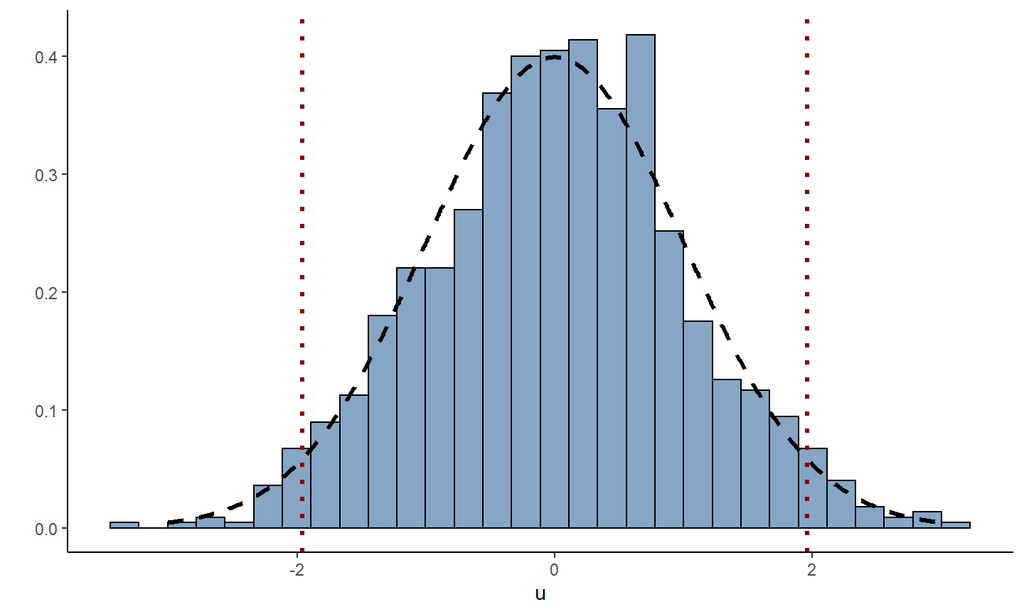

## Egymintás t-próba nulleloszlása

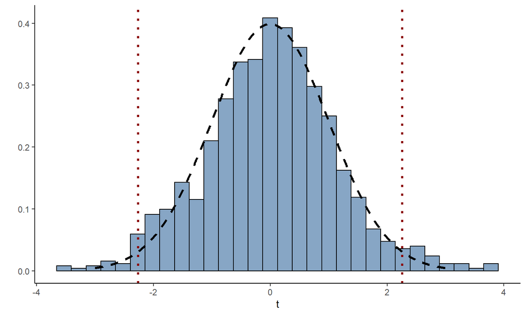

## Amit mi fogunk tenni

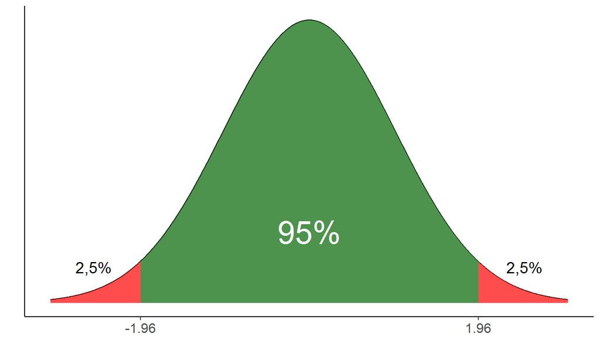

## Amit az SPSS (és tsai) tesz

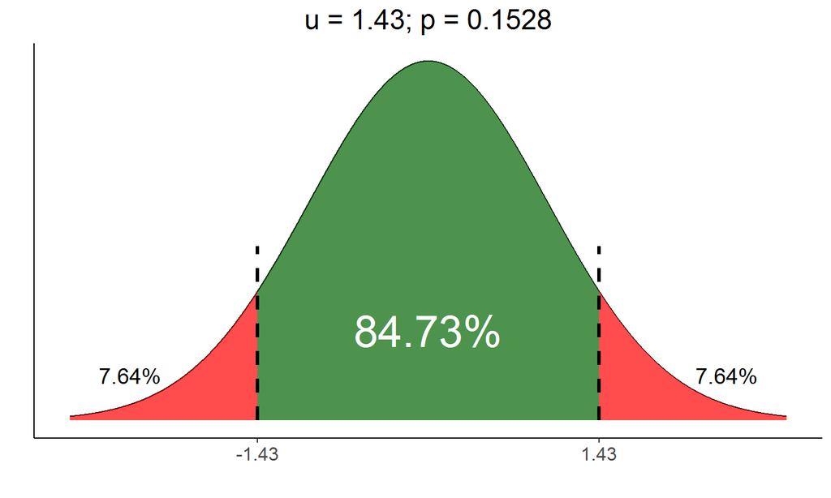

## Ha a nullhipotézis nem igaz

\(\mu = 170; m = 165; \sigma = 7, N = 10\)

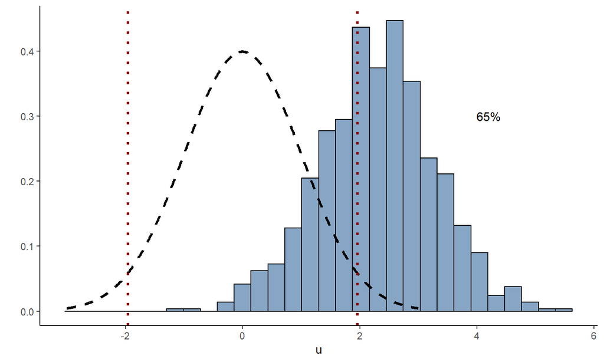

## Ha becsült szórással dolgozunk

\(\mu = 170; m = 165; (\sigma = 7), N = 10\)

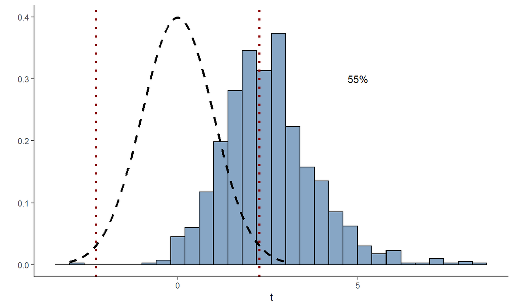

## Nagyobb elemszámnál

\(\mu = 170; m = 165; \sigma = 7, N = 100\)

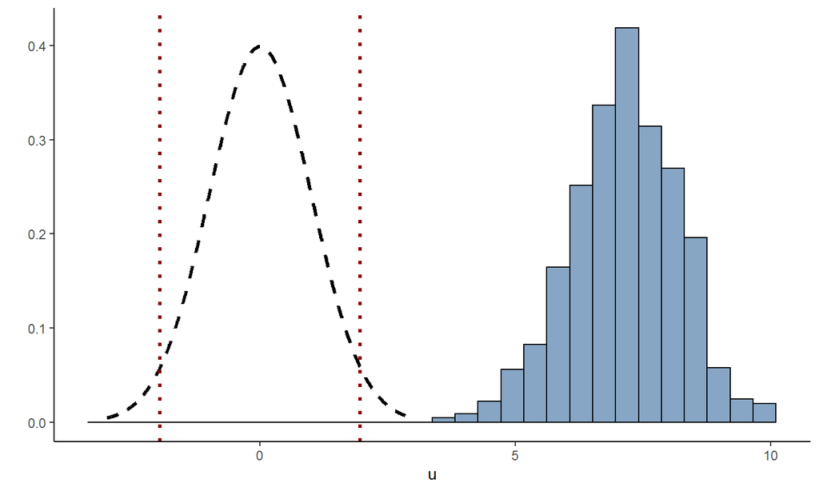

## Néhány példa

- \(N = 200; \overline{X}=171.5; \sigma = 7.0; m = 170; \alpha = 0.05\)
- \(N = 100; \overline{X}=98.7; \sigma = 10.0; m = 100; \alpha = 0.10\)
- \(N = 30; \overline{X}=167.2; s^* = 6.5; m = 170; \alpha = 0.05\)
- \(N = 100; \overline{X}=205.0; s^* = 41.0; m = 200; \alpha = 0.01\)

## 1. feladat

\(N = 200; \overline{X}=171.5; \sigma = 7.0; m = 170; \alpha = 0.05\)

## 1. feladat

\(N = 200; \overline{X}=171.5; \sigma = 7.0; m = 170; \alpha = 0.05\)

\[H_0: \mu = 170\] \[H_1: \mu \ne 170\]

## 1. feladat

\(N = 200; \overline{X}=171.5; \sigma = 7.0; m = 170; \alpha = 0.05\)

\[H_0: \mu = 170\] \[H_1: \mu \ne 170\] \[u=\frac{171.5-170}{\frac{7.0}{\sqrt{200}}}=3.03\]

## 1. feladat

\(N = 200; \overline{X}=171.5; \sigma = 7.0; m = 170; \alpha = 0.05\)

\[H_0: \mu = 170\] \[H_1: \mu \ne 170\] \[u=\frac{171.5-170}{\frac{7.0}{\sqrt{200}}}=3.03\] \[\pm z_{0.975} = \pm 1.96\]

## 1. feladat

\(N = 200; \overline{X}=171.5; \sigma = 7.0; m = 170; \alpha = 0.05\)

\[H_0: \mu = 170\] \[H_1: \mu \ne 170\] \[u=\frac{171.5-170}{\frac{7.0}{\sqrt{200}}}=3.03\] \[\pm z_{0.975} = \pm 1.96\] A különbség \(\alpha = 0.05\) szignifikanciaszint mellett szignifikáns

## 1. feladat

\(N = 200; \overline{X}=171.5; \sigma = 7.0; m = 170; \alpha = 0.05\)

\[H_0: \mu = 170\] \[H_1: \mu \ne 170\] \[u=\frac{171.5-170}{\frac{7.0}{\sqrt{200}}}=3.03\] \[\pm z_{0.975} = \pm 1.96\] A különbség \(\alpha = 0.05\) szignifikanciaszint mellett szignifikáns

SPSS: p = 0.002

## 2. feladat

\(N = 100; \overline{X}=98.7; \sigma = 10.0; m = 100; \alpha = 0.10\)

## 2. feladat

\(N = 100; \overline{X}=98.7; \sigma = 10.0; m = 100; \alpha = 0.10\)

\[H_0: \mu = 100\] \[H_1: \mu \ne 100\]

## 2. feladat

\(N = 100; \overline{X}=98.7; \sigma = 10.0; m = 100; \alpha = 0.10\)

\[H_0: \mu = 100\] \[H_1: \mu \ne 100\] \[u=\frac{98.7-100}{\frac{10.0}{\sqrt{100}}}=-1.30\]

## 2. feladat

\(N = 100; \overline{X}=98.7; \sigma = 10.0; m = 100; \alpha = 0.10\)

\[H_0: \mu = 100\] \[H_1: \mu \ne 100\] \[u=\frac{98.7-100}{\frac{10.0}{\sqrt{100}}}=-1.30\] \[\pm z_{0.950} = \pm 1.64\]

## 2. feladat

\(N = 100; \overline{X}=98.7; \sigma = 10.0; m = 100; \alpha = 0.10\)

\[H_0: \mu = 100\] \[H_1: \mu \ne 100\] \[u=\frac{98.7-100}{\frac{10.0}{\sqrt{100}}}=-1.30\] \[\pm z_{0.950} = \pm 1.64\] A különbség \(\alpha = 0.10\) szignifikanciaszint mellett nem szignifikáns

## 2. feladat

\(N = 100; \overline{X}=98.7; \sigma = 10.0; m = 100; \alpha = 0.10\)

\[H_0: \mu = 100\] \[H_1: \mu \ne 100\] \[u=\frac{98.7-100}{\frac{10.0}{\sqrt{100}}}=-1.30\] \[\pm z_{0.950} = \pm 1.64\] A különbség \(\alpha = 0.10\) szignifikanciaszint mellett nem szignifikáns

SPSS: p = 0.194

## 3. feladat

\(N = 30; \overline{X}=167.2; s^* = 6.5; m = 170; \alpha = 0.05\)

## 3. feladat

\(N = 30; \overline{X}=167.2; s^* = 6.5; m = 170; \alpha = 0.05\)

\[H_0: \mu = 170\] \[H_1: \mu \ne 170\]

## 3. feladat

\(N = 30; \overline{X}=167.2; s^* = 6.5; m = 170; \alpha = 0.05\)

\[H_0: \mu = 170\] \[H_1: \mu \ne 170\] \[t=\frac{167.2-170}{\frac{6.5}{\sqrt{30}}}=-2.36\]

## 3. feladat

\(N = 30; \overline{X}=167.2; s^* = 6.5; m = 170; \alpha = 0.05\)

\[H_0: \mu = 170\] \[H_1: \mu \ne 170\] \[t=\frac{167.2-170}{\frac{6.5}{\sqrt{30}}}=-2.36\] \[\pm t_{0.975;29} = \pm 2.05\]

## 3. feladat

\(N = 30; \overline{X}=167.2; s^* = 6.5; m = 170; \alpha = 0.05\)

\[H_0: \mu = 170\] \[H_1: \mu \ne 170\] \[t=\frac{167.2-170}{\frac{6.5}{\sqrt{30}}}=-2.36\] \[\pm t_{0.975;29} = \pm 2.05\] A különbség \(\alpha = 0.05\) szignifikanciaszint mellett szignifikáns

## 3. feladat

\(N = 30; \overline{X}=167.2; s^* = 6.5; m = 170; \alpha = 0.05\)

\[H_0: \mu = 170\] \[H_1: \mu \ne 170\] \[t=\frac{167.2-170}{\frac{6.5}{\sqrt{30}}}=-2.36\] \[\pm t_{0.975;29} = \pm 2.05\] A különbség \(\alpha = 0.05\) szignifikanciaszint mellett szignifikáns

SPSS: p = 0.025

## 4. feladat

\(N = 100; \overline{X}=205.0; s^* = 41.0; m = 200; \alpha = 0.01\)

## 4. feladat

\(N = 100; \overline{X}=205.0; s^* = 41.0; m = 200; \alpha = 0.01\)

\[H_0: \mu = 200\] \[H_1: \mu \ne 200\]

## 4. feladat

\(N = 100; \overline{X}=205.0; s^* = 41.0; m = 200; \alpha = 0.01\)

\[H_0: \mu = 200\] \[H_1: \mu \ne 200\] \[t=\frac{205.0-200}{\frac{41.0}{\sqrt{100}}}=1.22\]

## 4. feladat

\(N = 100; \overline{X}=205.0; s^* = 41.0; m = 200; \alpha = 0.01\)

\[H_0: \mu = 200\] \[H_1: \mu \ne 200\] \[t=\frac{205.0-200}{\frac{41.0}{\sqrt{100}}}=1.22\] \[\pm t_{0.995;60} = \pm 2.66\]

## 4. feladat

\(N = 100; \overline{X}=205.0; s^* = 41.0; m = 200; \alpha = 0.01\)

\[H_0: \mu = 200\] \[H_1: \mu \ne 200\] \[t=\frac{205.0-200}{\frac{41.0}{\sqrt{100}}}=1.22\] \[\pm t_{0.995;60} = \pm 2.66\] A különbség \(\alpha = 0.01\) szignifikanciaszint mellett nem szignifikáns

## 4. feladat

\(N = 100; \overline{X}=205.0; s^* = 41.0; m = 200; \alpha = 0.01\)

\[H_0: \mu = 200\] \[H_1: \mu \ne 200\] \[t=\frac{205.0-200}{\frac{41.0}{\sqrt{100}}}=1.22\] \[\pm t_{0.995;60} = \pm 2.66\] A különbség \(\alpha = 0.01\) szignifikanciaszint mellett nem szignifikáns

SPSS: p = 0.227

## Összegzés

Statisztikai hipotézisvizsgálat alapjai:

- nullhipotézis / ellenhipotézis
- első / másodfajú hiba
- próba és nulleloszlás
- szignifikanciaszint / próba ereje
- mit (nem) jelent a (nem) szignifikáns eredmény?

Egymintás próbák:

- ismert populációs szórással ⇒ u
- mintából becsült szórással ⇒ t